# Unstructured Data- Sentiment Analysis

## Eva He

### The Data

The data I will be working with the data about earning calls for the WWE.

```r
unzip('wweCalls.zip')
```

#### Step 1 Data Cleaning

Read all of the parsed transcripts into R using the `list.files()` function and read files from the resultant object.

```r
files <- list.files(pattern = ".csv")
data1 <- files %>%
  lapply(read.csv, stringsAsFactors=F) %>%
  bind_rows
```

Perform some initial exploration of the text and perform any initial cleaning.

##### initial exploration

```r
library(tm)
library(lubridate)
text <- data1 %>%
  mutate(text = str_replace_all(text,"amp;",""),
         text = str_replace_all(text,"\\(.*\\)",""),
         text = str_replace_all(text,"\\.",""),
         text = str_replace_all(text,",",""),
         text = str_replace_all(text,"--",""),
         text = str_replace_all(text,"\\?",""),
         text = str_replace_all(text,'"',""),
         text = str_replace_all(text,'\\$',""),
         text = str_replace_all(text,'\\%',""),
         text = str_replace_all(text,'\\-',""),
         text = str_replace_all(text,'\\[',"")，
         text = str_replace_all(text,'\\]',""),
         text = tolower(text),
         text = str_squish(text),
         text = str_squish(text)，
         text = removeWords(text, words = stopwords("en")),
         date = dmy(date))
```

```r
rawfiles <- read.csv("wwe_raw_27_Oct_16.csv",stringsAsFactors = F)

wwe <- data.frame(rawfiles[5:7,1])
colnames(wwe) <- "nat"
wwe <- wwe %>%
  separate(nat,c("name","title"),sep =" – ") %>%
  mutate(organization = str_sub(rawfiles[1,1],1,-11),
         organization = str_replace_all(organization,"\\,",""))

otcom <- data.frame(rawfiles[9:15,1])
colnames(otcom) <- "nac"
otcom <- otcom %>%
  separate(nac,c("name","organization"),sep =" – ") %>%
  mutate(title = str_sub(rawfiles[8,],1,-2))
otcom[7,3] <- NA

rawdata <- rbind(wwe,otcom)
rawdata <- rawdata %>%
  mutate(label = 1)

rawfiles1 <- data.frame(rawfiles[15:175,1])
colnames(rawfiles1) <- "pat"
rawfiles1$pat <- as.character(rawfiles1$pat)

rawfiles1 <- rawfiles1 %>%
  mutate(pat=str_replace_all(pat,"^Operator ","Operator"))

rawdata1 <- right_join(rawdata,rawfiles1,by=c("name"="pat"))
record <- as.numeric(which(rawdata1$label==1))


rawdata2 <- rawdata1 %>%
  filter(label == 1)

rawtext <- data.frame(matrix(ncol = 1,nrow = 0))
colnames(rawtext) <- "text"

for(k in 1:(length(record)-1)){
  k = as.numeric(k)
  a = as.numeric(record[k]+1)
  b = as.numeric(record[k+1]-1)
  textmsg=data.frame(text =paste0(rawfiles1[a:b,1],collapse = " "))
  rawtext <- rbind(rawtext,textmsg)
}
lasttext <- data.frame(text = paste0(rawfiles1[158:161,1],collapse = " "))
rawtext <- rbind(rawtext,lasttext)

rawfinal <- cbind(rawdata2,rawtext)
rawfinal <- rawfinal %>%
  mutate(ticker = str_sub(rawfiles[1,1],-4,-2), # wwe
  quarter = str_sub(rawfiles[2,1],1,2), #q3
  date = str_sub(rawfiles[3,1],1,-15),
  date = "27-Oct-16") #date)

#The second raw file

rawfilesjul <- read.csv("wwe_raw_28_Jul_16.csv",stringsAsFactors = F)

wwejul <- data.frame(rawfilesjul[5:7,1])
colnames(wwejul) <- "nat"
wwejul <- wwejul %>%
  separate(nat,c("name","title"),sep =" - ") %>%
  mutate(organization = str_sub(rawfilesjul[1,1],1,-11),
         organization = str_replace_all(organization,"\\,",""))

otcomjul <- data.frame(rawfilesjul[9:15,1])
colnames(otcomjul) <- "nac"
otcomjul <- otcomjul %>%
  separate(nac,c("name","organization"),sep =" - ") %>%
  mutate(title = str_sub(rawfilesjul[8,],1,-2))
otcomjul[7,3] <- NA

rawdatajul <- rbind(wwejul,otcomjul)
rawdatajul <- rawdatajul %>%
  mutate(label = 1)

rawfilesjul1 <- data.frame(rawfilesjul[15:137,1])
colnames(rawfilesjul1) <- "pat"
rawfilesjul1$pat <- as.character(rawfilesjul1$pat)

rawfilesjul1 <- rawfilesjul1 %>%
  mutate(pat=str_replace_all(pat,"^Operator ","Operator"))

rawdatajul1 <- right_join(rawdatajul,rawfilesjul1,by=c("name"="pat"))
recordjul <- as.numeric(which(rawdatajul1$label==1))


rawdatajul2 <- rawdatajul1 %>%
  filter(label == 1)

rawtextjul <- data.frame(matrix(ncol = 1,nrow = 0))
colnames(rawtextjul) <- "text"

for(k in 1:(length(recordjul)-1)){
  k = as.numeric(k)
  a = as.numeric(recordjul[k]+1)
  b = as.numeric(recordjul[k+1]-1)
  textmsgjul=data.frame(text =paste0(rawfilesjul1[a:b,1],collapse = " "))
  rawtextjul <- rbind(rawtextjul,textmsgjul)
}
lasttextjul <- data.frame(text = paste0(rawfilesjul1[120:123,1],collapse = " "))
rawtextjul <- rbind(rawtextjul,lasttextjul)

rawfinaljul <- cbind(rawdatajul2,rawtextjul)
rawfinaljul <- rawfinaljul %>%
  mutate(ticker = str_sub(rawfilesjul[1,1],-4,-2), # wwe
  quarter = str_sub(rawfilesjul[2,1],1,2), #q3
  date = str_sub(rawfilesjul[3,1],1,-15),
  date = "28-Jul-2016")


rawtwofinal <- rbind(rawfinal,rawfinaljul)
rawtwofinal <- subset(rawtwofinal,select = -label)
#rawtwofinal$date <- as.Date(rawtwofinal$date,format="%y-%m-%d")

data2 <- data.frame(matrix(ncol = 13,nrow = 100))
colnames(data2) <- colnames(data1)


data2 <- data2 %>%
  mutate(name= tolower(rawtwofinal$name),
         title = rawtwofinal$title,
         organization = rawtwofinal$organization,
         text = rawtwofinal$text,
         ticker = rawtwofinal$ticker,
         quarter = rawtwofinal$quarter,
         date = rawtwofinal$date)

racenname <- data1 %>%
  select(likelyRace,name)

unqiueracenname <- unique(racenname)

data2 <- left_join(data2,unqiueracenname, by =c("name"="name"))
data2 <- data2 %>%
  mutate(likelyRace.x = likelyRace.y) %>%
  select(-likelyRace.y)

colnames(data2) <- colnames(data1)

data1 <- data1 %>%
  filter(date != is.na(date))
data2 <- rbind(data1,data2)
```

#### Step 2

Perform sentiment analyses on the texts. Given that these are earnings calls, I used Loughran and McDonald’s lexicon.

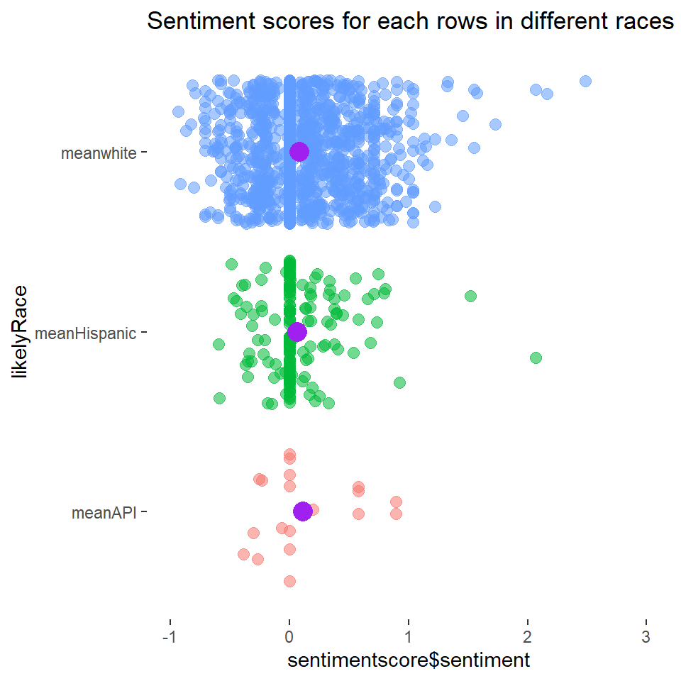

```r
library(textdata)
library(tidytext)
library(sentimentr)
library(lexicon)
library(magrittr)
library(tokenizers)
library(ggplot2)


nrcWord <- textdata::lexicon_nrc()

nrcValues <- lexicon::hash_sentiment_nrc

nrcDominance <- textdata::lexicon_nrc_vad()

sentimentscore <- sentiment(text$text,polarity_dt =lexicon::hash_sentiment_loughran_mcdonald)

## Analysis by rows
sentimentscore <- sentimentscore %>%
  group_by(element_id) %>%
  summarize(sentiment=mean(sentiment))
text <- cbind(text,sentimentscore$sentiment)

text <- text %>%
  filter(likelyRace!=is.na(likelyRace))

race_means <- text %>%
  select(likelyRace,`sentimentscore$sentiment`) %>%
  group_by(likelyRace) %>%
  summarize(`sentimentscore$sentiment` = mean(`sentimentscore$sentiment`))

p1 <- ggplot(text)+
  geom_jitter(aes(x = `sentimentscore$sentiment`, y = likelyRace,color = likelyRace,alpha = 0.25),size = 2.6)+
  geom_point(data=race_means,aes(x = `sentimentscore$sentiment`, y = likelyRace,size = 3), col="purple")+
    theme(legend.position = "none",panel.grid.major = element_blank(), panel.grid.minor = element_blank(),panel.border = element_blank(),panel.background = element_blank())+xlim(c(-1,3))+
  ggtitle("Sentiment scores for each rows in different races")
print(p1)
```

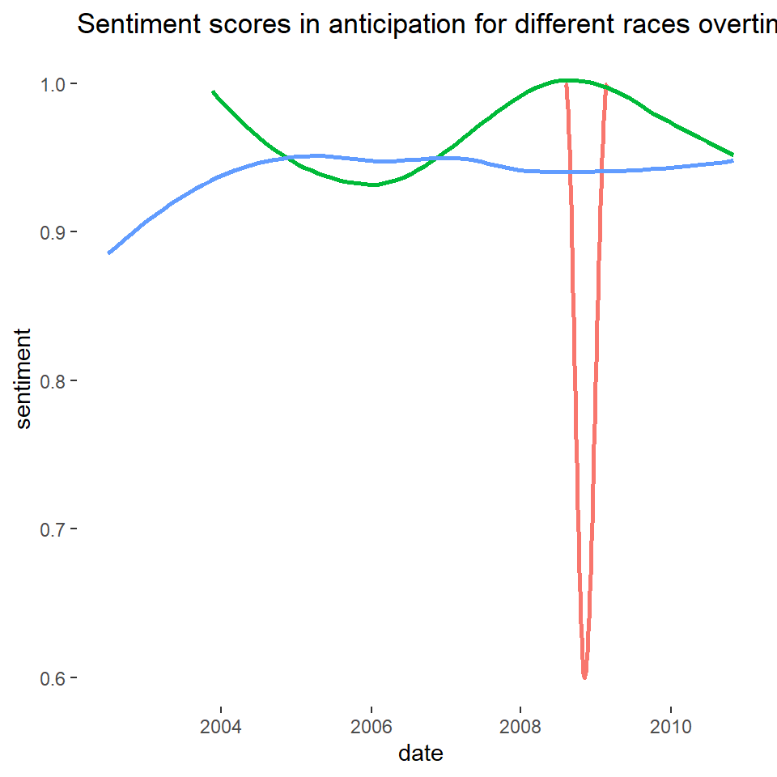

```r
# filter one date to analyze
text1 <- text %>%
  select(likelyRace,date,text) %>%
  filter(likelyRace!=is.na(likelyRace)) %>%
  group_by(likelyRace,date) %>%
  summarise(text = paste0(text,collapse = ""),
         text = str_squish(text))
text1 <- unique(text1)


# choose a emotion
emotion <- nrcWord %>%
  filter(sentiment =="anticipation")
race <- unique(text1$likelyRace)
calldates <- unique(text1$date)

sentimentresult = data.frame(matrix(ncol = 3,nrow = 0))
for(i in 1:length(race)){
  i = as.numeric(i)
  for (j in 1:length(calldates)) {
    j = as.numeric(j)
tokens <-  text1 %>%
  filter(likelyRace == race[i],
         date==date[j]) %>%
  unnest_tokens(tbl = ., output = word, input = text)
tokens <- tokens[,3]
testing <- tokens %>%
inner_join(emotion)
testing <- testing %>%
  select(word)
colnames(testing) <- 'x'
testing1 <- nrcValues %>%
  inner_join(testing,nrcValues,by = c("x","x")) %>%
  summarize(n = nrow(.), sentSum = sum(y)) %>%
  mutate(sentiment = sentSum / n,
         likelyrace = race[i],
         date = calldates[j])
sentimentresult = rbind(sentimentresult,testing1)
}
}

sentimentresult <- sentimentresult %>%
  filter(n != 0)
p2 <- ggplot(sentimentresult)+
  geom_smooth(aes(x = date, y =sentiment,color = likelyrace),se = FALSE)+
  ggtitle("Sentiment scores in anticipation for different races overtime")+
    theme(legend.position = "none",panel.grid.major = element_blank(), panel.grid.minor = element_blank(),panel.border = element_blank(),panel.background = element_blank())
print(p2)
```